# Computer Lab 3 - Gun Laws

Ralf Becker

# Introduction

In this computer lab you will be practicing the following

- Creating time series plots with ggplot
- Merge datafiles
- Performing hypothesis tests to test the equality of means
- Estimate and interpret regressions

Let’s start by loading some useful packages

```r
library(readxl)       # enable the read_excel function
library(tidyverse)    # for almost all data handling tasks
library(ggplot2)      # plotting toolbox
library(stargazer)    # for nice regression output
```

# Context

Here we are looking at replicating aspects of this paper:

Siegel et al (2019) The Impact of State Firearm Laws on Homicide and Suicide Deaths in the USA, 1991–2016: a Panel Study, J Gen Intern Med 34(10):2021–8.

this is the paper which we will replicate throughout the unit in order to demonstrate some Diff-in-Diff techniques (not in this session but later).

# Data Import

Import the data from the “US_Gun_example.csv” file. Recall, make sure the file (from the Week 3 BB page) is saved in your working directory, that you set the working directory correctly and that you set the the `na=` option in the `read.csv` function to the value in which missing values are coded in the csv file. To do this correctly you will have to open the csv file (with your spreadsheet software, e.g. Excel) and check for instance cell G9. The `stringsAsFactors = TRUE` option in `read.csv` automatically converts character variables into factor (categorical) variables. This is useful when yo know that these variables represent categories (like here states).

```r
setwd("YOUR WORKING DORECTORY")
data <- read.csv(XXXX,na="XXXX", stringsAsFactors = TRUE)
str(data)
```

```
## 'data.frame':    1071 obs. of  19 variables:
##  $ X                : int  1 2 3 4 5 6 7 8 9 10 ...
##  $ Year             : int  2001 2001 2001 2001 2001 2001 2001 2001 2001 2001 ...
##  $ State_code       : Factor w/ 51 levels "AK","AL","AR",..: 1 2 3 4 5 6 7 8 9 10 ...
##  $ State            : Factor w/ 51 levels "Alabama","Alaska",..: 2 1 4 3 5 6 7 9 8 10 ...
##  $ Population       : int  633687 4467634 2691571 5273477 34479458 4425687 3432835 574504 795699 16356966 ...
##  $ Mechanism        : Factor w/ 1 level "Firearm": 1 1 1 1 1 1 1 1 1 1 ...
##  $ pol_ubc          : int  0 0 0 0 1 0 1 NA 0 0 ...
##  $ pol_vmisd        : int  0 0 0 0 1 0 1 NA 1 0 ...
##  $ pol_mayissue     : int  0 1 0 0 1 1 1 NA 1 0 ...
##  $ Age.Adjusted.Rate: num  14.83 16.41 15.27 15.92 9.32 ...
##  $ logy             : num  2.7 2.8 2.73 2.77 2.23 ...
##  $ ur               : num  6.28 5.18 4.76 4.72 5.47 ...
##  $ law.officers     : int  1821 15303 7538 18548 106244 15172 9825 4716 2964 63041 ...
##  $ law.officers.pc  : num  287 343 280 352 308 ...
##  $ vcrime           : int  3696 19203 12042 28275 210661 15334 11387 4845 4845 129839 ...
##  $ vcrime.pc        : num  583 430 447 536 611 ...
##  $ alcc.pc          : num  2.67 1.86 1.74 2.5 2.2 ...
##  $ incarc           : int  3033 24741 11489 27710 157142 14888 17507 NA 6841 72404 ...
##  $ incarc.pc        : num  479 554 427 525 456 ...
```

You got it right if the output from `str(data)` looks like the above.

# Importing and Merging additional datasets

## Age proportion

A variable that is used in the paper but not yet included in the “US_Gun_example.csv” dataset is the age structure of a state’s population. In the Siegel et al. (2019) paper you will find that they use a variable called “Percent male among population ages 15-29”. We shall attempt to use a different variable “Proportion of 18-24 year olds in the population”. You will see below that adding this data to our datasets require a bit of work. With enough work we could add the data used in the paper, but for today’s exercise we will make our life a little easier. But the work done in what follows is quite typical of the work that needs doing when you merge data.

We shall import a new datafile that contains some of that information. The data are sourced from the [StatsAmerica website](https://www.statsamerica.org/downloads/default.aspx). Download the “US states population age and sex.csv” file from the Week 3 BB page and save it into your working folder.

```r
data_pop <- read.csv(XXXX, stringsAsFactors = TRUE)
str(data_pop)
```

```
## 'data.frame':    63882 obs. of  17 variables:
##  $ IBRC_Geo_ID        : int  0 0 0 0 0 0 0 0 0 0 ...
##  $ Statefips          : int  0 0 0 0 0 0 0 0 0 0 ...
##  $ Countyfips         : int  0 0 0 0 0 0 0 0 0 0 ...
##  $ Description        : Factor w/ 3197 levels "Abbeville County, SC",..: 2892 2892 2892 2892 2892 2892 2892 2892 2892 2892 ...
##  $ Year               : int  2000 2001 2002 2003 2004 2005 2006 2007 2008 2009 ...
##  $ Total.Population   : int  282162411 284968955 287625193 290107933 292805298 295516599 298379912 301231207 304093966 306771529 ...
##  $ Population.0.4     : int  19178293 19298217 19429192 19592446 19785885 19917400 19938883 20125962 20271127 20244518 ...
##  $ Population.5.17    : int  53197896 53372958 53507265 53508312 53511850 53606269 53818831 53893443 53833475 53889649 ...
##  $ Population.18.24   : int  27315274 27992652 28480708 28916746 29302179 29441546 29602839 29808025 30194274 30530346 ...
##  $ Population.25.44   : int  84973340 84523274 83990295 83398001 83066831 82764185 82638980 82509693 82399959 82211153 ...
##  $ Population.45.64   : int  62428040 64491563 66695526 68828899 70935234 73137401 75216272 77068373 78617510 80272688 ...
##  $ Population.65.     : int  35069568 35290291 35522207 35863529 36203319 36649798 37164107 37825711 38777621 39623175 ...
##  $ Population.Under.18: int  72376189 72671175 72936457 73100758 73297735 73523669 73757714 74019405 74104602 74134167 ...
##  $ Population.18.54   : int  150287588 151902194 152463197 153134701 153998940 154701635 155527978 156257657 157054680 157608587 ...
##  $ Population.55.     : int  59498634 60395586 62225539 63872474 65508623 67291295 69094220 70954145 72934684 75028775 ...
##  $ Male.Population    : int  138443407 139891492 141230559 142428897 143828012 145197078 146647265 148064854 149489951 150807454 ...
##  $ Female.Population  : int  143719004 145077463 146394634 147679036 148977286 150319521 151732647 153166353 154604015 155964075 ...
```

This file has 63882 rows. How many would you have expected if there were 51 states and 21 years for each state? Exactly, 1,071, which is the number of rows in the `data` object. You need to figure out why there are so many rows before we can merge data into the `data` dataframe. Have a look at the spreadsheet. Can you see the problem/issue?

The spreadsheet includes data for every county and not only for the whole state of Alabama. For instance you see that some rows have in the description column only the name of a state and others have the name of a county. To illustrate this look at the following snippet from the data table:

```r
data_pop[1979:1982,]
```

|  | IBRC_Geo_ID | Statefips | Countyfips | Description | Year | Total.Population | Population.0.4 | Population.5.17 | Population.18.24 | Population.25.44 | Population.45.64 | Population.65. | Population.Under.18 | Population.18.54 | Population.55. | Male.Population | Female.Population |
| --- | --- | --- | --- | --- | --- | --- | --- | --- | --- | --- | --- | --- | --- | --- | --- | --- | --- |
| 1979 | 4000 | 4 | 0 | Arizona | 2018 | 7158024 | 432798 | 1204802 | 686858 | 1863583 | 1713811 | 1256172 | 1637600 | 3399827 | 2120597 | 3560169 | 3604059 |
| 1980 | 4000 | 4 | 0 | Arizona | 2019 | 7278717 | 429788 | 1210448 | 693844 | 1903120 | 1732884 | 1308633 | 1640236 | 3449054 | 2189427 | 3622802 | 3669041 |
| 1981 | 4001 | 4 | 1 | Apache County, AZ | 2000 | 69507 | 6281 | 20398 | 6601 | 17384 | 13070 | 5773 | 26679 | 31663 | 11165 | 34441 | 35066 |
| 1982 | 4001 | 4 | 1 | Apache County, AZ | 2001 | 67863 | 5821 | 19498 | 6530 | 16785 | 13312 | 5917 | 25319 | 31174 | 11370 | 33725 | 34138 |

Note that in lines 1979 and 1980 we are having data for the whole state of Arizona and in lines 1981 and 1982 you find data for Apache County (in Arizona). We only want statewide data. In the above snippet you can see that there is a variable called `Countyfips` which is a numerical code for the different counties. The statewide data have a value of 0 in the `Countyfips` variable. You should confirm (by looking at the data) that this is true for the other states as well.

One additional aspect of the data is that you will see that population data are only available from 2000 to 2019. This is not aligned with the 2001 to 2021 date range in `data`. The common years are 2001 to 2019 and therefore we should expect to get 969 (=51*19) observations which we can match.

Let us first filter out the statewide data and remove the county level data.

```r
data_pop <- data_pop %>% filter(Countyfips == 0)  # we only keep data with Countyfips equal to 0
```

```r
unique(data_pop$Description)
```

```
##  [1] U.S.                 Alabama              Alaska
##  [4] Arizona              Arkansas             California
##  [7] Colorado             Connecticut          Delaware
## [10] District of Columbia Florida              Georgia
## [13] Hawaii               Idaho                Illinois
## [16] Indiana              Iowa                 Kansas
## [19] Kentucky             Louisiana            Maine
## [22] Maryland             Massachusetts        Michigan
## [25] Minnesota            Mississippi          Missouri
## [28] Montana              Nebraska             Nevada
## [31] New Hampshire        New Jersey           New Mexico
## [34] New York             North Carolina       North Dakota
## [37] Ohio                 Oklahoma             Oregon
## [40] Pennsylvania         Rhode Island         South Carolina
## [43] South Dakota         Tennessee            Texas
## [46] Utah                 Vermont              Virginia
## [49] Washington           West Virginia        Wisconsin
## [52] Wyoming              Puerto Rico
## 3197 Levels: Abbeville County, SC Acadia Parish, LA ... Ziebach County, SD
```

You will immediately see that there are also observations for the entire U.S.. So, let’s extract the data that are from states and years which are also represented in `data`, our original dataset. Complete the following code for this task.

```r
state_list <- unique(data$XXXX)  # creates a list with state names in data
year_list <- XXXX(XXXX$Year)    # creates a list of years in data
data_pop <- data_pop %>% filter(Description %in% XXXX) %>%
                            filter(XXXX XXXX year_list)
```

You got it right if `data_pop` has 969 observations and you can replicate the following table:

```r
summary(data_pop$Total.Population)
```

```
##     Min.  1st Qu.   Median     Mean  3rd Qu.     Max.
##   494657  1651059  4219239  6041273  6859789 39512223
```

Let’s look at the variables that are contained in this datafile.

```r
names(data_pop)
```

```
##  [1] "IBRC_Geo_ID"         "Statefips"           "Countyfips"
##  [4] "Description"         "Year"                "Total.Population"
##  [7] "Population.0.4"      "Population.5.17"     "Population.18.24"
## [10] "Population.25.44"    "Population.45.64"    "Population.65."
## [13] "Population.Under.18" "Population.18.54"    "Population.55."
## [16] "Male.Population"     "Female.Population"
```

We shall not merge all of these variables into `data` but only what we want, namely the “Proportion of 18-24 year olds in the population”. That is actually not one of the variables in the list. There is the population between 18 and 24 (`Population.18.24`) and the overall population (`Total.Population`) and we can calculate the proportion we need as a new variable, `prop18.24`. Complete the following code:

```r
data_pop$prop18.24 <- 100*XXXX$Population.18.24/data_pop$XXXX
```

You get it right if you can replicate these summary statistics for the new variable.

```r
summary(data_pop$prop18.24)
```

```
##    Min. 1st Qu.  Median    Mean 3rd Qu.    Max.
##   7.955   9.463   9.867   9.944  10.282  14.385
```

Now we select only the variables we wish to merge into `data`, namely only `prop18.24`. However, in order to merge the data into `data` we also need the year (`Year`) and state name (`Description`).

```r
data_pop <- data_pop %>%  select(Year, Description, prop18.24)
```

It is easiest to merge datafiles if the variables on which we want to match (state name and Year) are called the same in both datasets (`data` and `data_pop`). This is true for the `Year` variable, but not for the state name (`State` in `data` and `Description` in `data_pop`). Let’s fix that and change the state variable name in `data_pop` to `State`.

```r
names(data_pop)[names(data_pop)=="Describtion"] <- "State"
```

Then look at `names(data_pop)` and see whether you achieved what you wanted … no, you didn’t? The name has not changed? Sometimes you make a mistake but there is no error message. Look at the previous line again and try and figure out what the problem is, correct it and rename the variable. But the message here is an important one. Don’t assume that just because R ran your line and didn’t spit out an error message that everything you wanted to happen did happen. You should always check whether the result is as expected.

```r
names(data_pop)[names(data_pop)=="Description"] <- "State"
```

Now we are in a position to merge the two datafiles.

```r
data2 <- merge(data,data_pop)
```

As result your datafile has gained one variable, `prop18.24`, but lost a few rows. By default, the merge function deletes rows for which it did not have matching rows in both datafiles and therefore all 2020 and 2021 observations have gone. Look at the help for merge (by typing `?merge` into the console) and find the change you need in the above line to make sure that we keep all 1071 observations from the `data` dataframe. Then re-run the above line.

```r
data2 <- merge(data,data_pop, all.x = TRUE)
```

Your `data2` dataframe should end up with 1071 rows and 20 variables.

## Region information

Merging datasets is a super important skill, so let’s practice this here again. We wish to differentiate between different regions in the U.S. In your `data2` dataframe one of the information is the state, coded by both `State` and `State_code` variables. What we need is an additional variable that tells you which region the state is in.

So, for instance:

| State | State code | Region |
| --- | --- | --- |
| Alabama | AL | South |
| Alaska | AK | West |
| Arizona | AZ | West |

You will first have to find a dataset on the internet that maps states to regions. Go to your favorite search engine and search for something like “csv us States and regions”. Alternatively you could enlist the help of an AI. For instance you could go to Google Bart and ask something like “create a csv file that maps US states to regions”. Then save that file into your working directory and merge the Region variable into your `data2` file.

```r
states_info <- read_xlsx("../data/states.xlsx")
# The variable names may be different in your file
states_info <- states_info %>%  select(STATEAB, Region)
names(states_info)[names(states_info)=="STATEAB"] <- "State_code"
data2 <- merge(data2, states_info)
```

Make sure that the region variable is called `Region` and that the State or State code variable name aligns with that in `data`. If you got it right the following code should give you the same result

```r
tab_regions <- data2 %>% select(State_code, Region) %>%
                      unique() %>%
                      group_by(Region) %>%
                      summarise(n = n()) %>%
                      print()
```

```
## # A tibble: 4 × 2
##   Region        n
##   <chr>     <int>
## 1 Midwest      12
## 2 Northeast     9
## 3 South        17
## 4 West         13
```

This table shows that there are 12 states in the Midwest region and 9 in the Northeast. Altogether the U.S. is divided into four regions.

# Plotting data as time-series

Here we will practice some time-series plotting. Let’s start with a simple plot for `prop18.24` for Florida. You googled the internet to find an example for how to create a time-series plot using ggplot and found the following lines which seem relevant. In the bit of code you did find on the internet you see the element `subset(dataset, country == "Brazil")`. This takes a dataframe called `dataset` and extracts all rows for which the variable `country` takes the value “Brazil”. Adjust this code to create the following plot from the data in your `data2`.

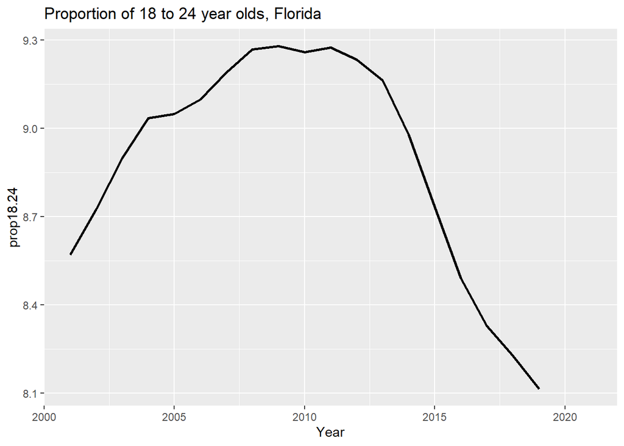

```r
g1 <- ggplot(subset(dataset, country == "Brazil"), aes(x=dates,y=deaths_weekly)) +
      geom_line(size=1) +
      ggtitle("Covid-19 weekly deaths, Brazil")
g1
```

Now you want to compare this proportion between Florida and Texas. As you create your graph you should be able to select the data from these two states by using `subset(data2, State %in% c("Florida","Texas"))`. How to create separate lines for the two states you learned in the Week 2 lecture (or better the accompanying code).

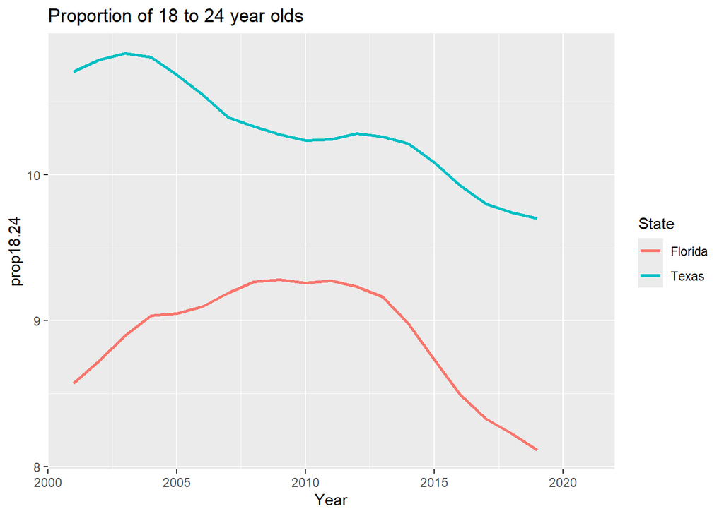

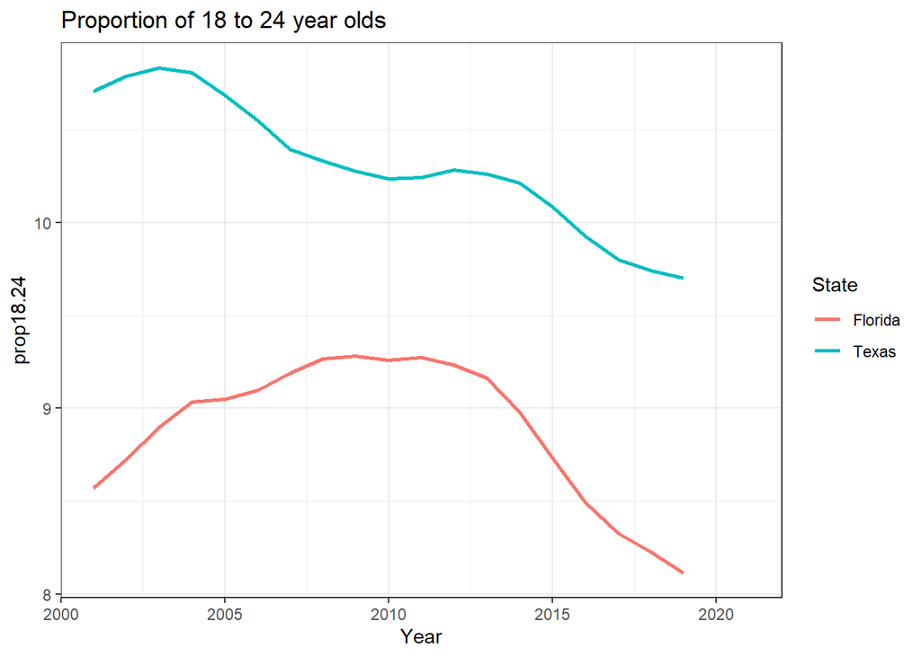

Check out the [GGplot cheat sheet](https://rstudio.github.io/cheatsheets/data-visualization.pdf) for more tricks and illustrations of the ggplot packages’ capabilities and other themes available.

# Average data over the sample period

What we now do is to aggregate or average data across the sample period. We shall use the awesome power of the tidyverse language to do this. We want to calculate the average `prop18.24`, the average rate of firearm deaths (`Age.Adjusted.Rate`), the average for `law.officers.pc` and the average of `ur` for each state.

```r
tab1 <- data2 %>%  group_by(State) %>%
          summarise(avg_prop18.24 = mean(prop18.24),
                    avg_fad.rate  = mean(Age.Adjusted.Rate),
                    avg_law.officers.pc = mean(law.officers.pc),
                    avg_ur = mean(ur)) %>%
          print()
```

```
## # A tibble: 51 × 5
##    State                avg_prop18.24 avg_fad.rate avg_law.officers.pc avg_ur
##    <fct>                        <dbl>        <dbl>               <dbl>  <dbl>
##  1 Alabama                         NA        18.5                 310.   6.04
##  2 Alaska                          NA        19.9                 274.   6.93
##  3 Arizona                         NA        15.3                 338.   6.26
##  4 Arkansas                        NA        17.0                 316.   5.55
##  5 California                      NA         8.40                314.   7.32
##  6 Colorado                        NA        12.4                 336.   5.33
##  7 Connecticut                     NA         5.22                275.   5.89
##  8 Delaware                        NA        10.4                 355.   5.32
##  9 District of Columbia            NA        18.1                 791.   7.40
## 10 Florida                         NA        11.9                 371.   5.69
## # ℹ 41 more rows
```

As you can see the code calculated the average values for the firearm death rate (for instance, on average there were 18.5 firearm deaths per 100,000 in Alabama per year), but the code did not calculate the average proportion of 18 to 24 year olds. We get “NA” for all states. The reason for that is that some of the `prop18.24` observations are not available, in particular the data for years 2020 and 2021. The `mean` function by default refuses to calculate the mean value if any of the data are “NA”s. However, there is a way to instruct the `mean` function to ignore missing values and calculate the mean value on the basis of the available data. Check the help for the mean function (type `?mean` into the console) to find the option you should add to the mean function to achieve this.

If you get it right you should be able to replicate the following table.

```
## # A tibble: 51 × 5
##    State                avg_prop18.24 avg_fad.rate avg_law.officers.pc avg_ur
##    <fct>                        <dbl>        <dbl>               <dbl>  <dbl>
##  1 Alabama                       9.86        18.5                 310.   6.04
##  2 Alaska                       10.4         19.9                 274.   6.93
##  3 Arizona                       9.93        15.3                 338.   6.26
##  4 Arkansas                      9.73        17.0                 316.   5.55
##  5 California                   10.2          8.40                314.   7.32
##  6 Colorado                      9.79        12.4                 336.   5.33
##  7 Connecticut                   9.17         5.22                275.   5.89
##  8 Delaware                      9.67        10.4                 355.   5.32
##  9 District of Columbia         12.5         18.1                 791.   7.40
## 10 Florida                       8.89        11.9                 371.   5.69
## # ℹ 41 more rows
```

It is possibly not good practice to calculate averages over different sample sizes (over 2001 to 2019 for `prop18.24` and over 2001 to 2021 for `Age.Adjusted.Rate`). We therefore repeat the calculation but only for the years up to and including 2019.

There is one mistake in the code and you should get an error message.

```r
tab1 <- data2 %>% filter(year <= 2019) %>%
          group_by(State) %>%
          summarise(avg_prop18.24 = mean(prop18.24, na.rm = TRUE),
                    avg_fad.rate  = mean(Age.Adjusted.Rate),
                    avg_law.officers.pc = mean(law.officers.pc),
                    avg_ur = mean(ur)) %>%
          print()
```

Fix the error to obtain the following table.

[output not shown]

Let’s create a few plots which show the average death numbers against some of our state specific information.

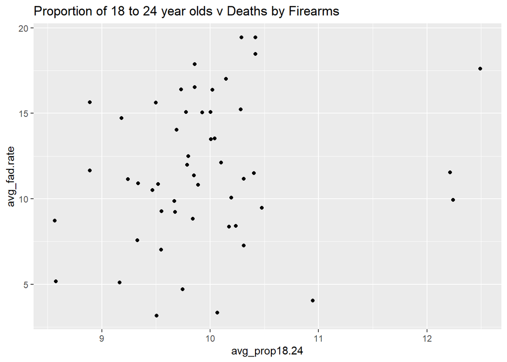

```r
ggplot(tab1,aes(avg_prop18.24,avg_fad.rate)) +
  geom_point() +
  ggtitle("Proportion of 18 to 24 year olds v Deaths by Firearms")
```

In order to demonstrate another trick in ggplot box of tricks we will also use the `Region` information.

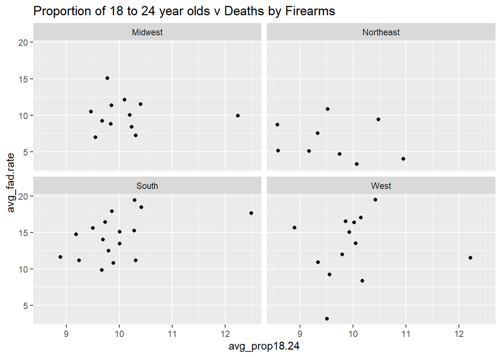

```r
ggplot(tab1,aes(avg_prop18.24,avg_fad.rate)) +
  geom_point() +
  facet_wrap(vars(Region)) +
  ggtitle("Proportion of 18 to 24 year olds v Deaths by Firearms")
```

Very neat indeed. What we learn from these scatterplots is that there is no obvious correlation between the average proportions of 18 to 24 year olds and the rate of firearm deaths.

# Testing for equality of means

We therefore continue to work with the data in `tab1`. In `tab2` we calculate regional averages.

```r
tab2 <- tab1 %>%
              group_by(Region) %>%
              summarise(RAvg_cases = mean(avg_fad.rate),
                        n = n()) %>% print()
```

```
## # A tibble: 4 × 3
##   Region    RAvg_cases     n
##   <chr>          <dbl> <int>
## 1 Midwest        10.1     12
## 2 Northeast       6.55     9
## 3 South          14.4     17
## 4 West           13.0     13
```

Let’s see whether we find the regional averages to be statistically significantly different. Say we compare the `avg_fad.rate` in the Northeast to that in the Midwest. So test the null hypothesis that $H_0: \mu_{NE}=\mu_{MW}$ (or $H_0: \mu_{NE}-\mu_{MW}=0$) against the alternative hypothesis that $H_A: \mu_{NE}\neq\mu_{MW}$, where $\mu$ represents the average firearm death rate (per 100,000 population) in states in the respective region over the sample period.

```r
test_data_NE <- tab1 %>%
  filter(Region == "Northeast")      # pick Northeast states

test_data_MW <- tab1 %>%
  filter(Region == "Midwest")      # pick Midwest states

t.test(test_data_NE$avg_fad.rate,test_data_MW$avg_fad.rate, mu=0)  # testing that mu = 0
```

```
##
##  Welch Two Sample t-test
##
## data:  test_data_NE$avg_fad.rate and test_data_MW$avg_fad.rate
## t = -3.2399, df = 15.565, p-value = 0.005282
## alternative hypothesis: true difference in means is not equal to 0
## 95 percent confidence interval:
##  -5.895230 -1.225443
## sample estimates:
## mean of x mean of y
##  6.548129 10.108465
```

The difference in the averages is 6.548 - 10.108 = -3.56 (more than 3 in 100,000 population). We get a t-test statistic of about -3.2. If in truth the two means were the same ($H_0$ was correct) then we should expect the test statistic to be around 0. Is -3.2 far enough away from 0 for us to conclude that we should stop supporting the null hypothesis? Is -3.2 large (in absolute terms) enough?

The answer is yes and the p-value does tell us that it is. The p-value is 0.005282 0.53%. This means that if the $H_0$ was correct, the probability of getting a difference of -3.56 (per 100,000 population) or a more extreme difference is 0.53%. We judge this probability to be too small for us to continue to support the $H_0$ and we reject the $H_0$. We do so as the p-value is smaller than any of the usual significance levels (10%, 5% or 1%).

We are not restricted to testing whether two population means are the same. You could also test whether the difference in the population is anything different but 0. Say a politician claims that evidently the firearm death rate rate in the Northeast is smaller by more than 3 per 100,000 population than the firearm death rate in the Midwest.

Here our $H_0$ is $H_0: \mu_{NE}=\mu_{MW}-3$ (or $\mu_{NE}-\mu_{MW}=-3$) and we would test this against an alternative hypothesis of $H_0: \mu_{NE}<\mu_{MW}-3$ (or $H_0: \mu_{NE}-\mu_{MW}<-3$). Here the statement of the politician is represented in the $H_A$.

```r
# testing that mu = -3
t.test(test_data_NE$avg_fad.rate,test_data_MW$avg_fad.rate, mu=-3, alternative = "less")
```

```
##
##  Welch Two Sample t-test
##
## data:  test_data_NE$avg_fad.rate and test_data_MW$avg_fad.rate
## t = -0.5099, df = 15.565, p-value = 0.3086
## alternative hypothesis: true difference in means is less than -3
## 95 percent confidence interval:
##       -Inf -1.638469
## sample estimates:
## mean of x mean of y
##  6.548129 10.108465
```

Note the following. The parameter `mu` now takes the value -3 as we are hypothesising that the difference in the means is -3 (or smaller than that in the $H_A$). Also, in contrast to the previous test we now care whether the deviation is less than -3. In this case we wonder whether it is really smaller. Hence we use the additional input into the test function, `alternative = "less"`. (The default for this input is `alternative = "two.sided"` and that is what is used, as in the previous case, if you don’t add it to the `t.test` function). Also check `?t.test` for an explanation of these optional input parameters.

So let’s perform another test. A Republican governor of a Southern state in the U.S. claims that the average firearm death rate in the South is just as big as the one in the West. Perform the appropriate hypothesis test.

```r
test_data_SO XXXX tab1 %>%
  filter(XXXX == "South")      # pick Southern states

XXXX <- tab1 XXXX
  XXXX(XXXX == "West")      # pick Western states

XXXX(XXXX$avg_fad.rate,XXXX$XXXX, XXXX=0)  # testing that mu = 0
```

```
##
##  Welch Two Sample t-test
##
## data:  test_data_SO$avg_fad.rate and test_data_WE$avg_fad.rate
## t = 1.0149, df = 19.808, p-value = 0.3224
## alternative hypothesis: true difference in means is not equal to 0
## 95 percent confidence interval:
##  -1.515748  4.384902
## sample estimates:
## mean of x mean of y
##  14.42065  12.98607
```

# Regression

To perform inference in the context of regressions it pays to use an additional package, the `car` package. So please load this package.

```r
library(car)
```

If you get an error message it is likely that you first have to install that package.

## Estimating and interpreting a regresison model

In the lecture we talked about the following regression (Lecture Week 2 - Regression Analysis - Example 3)

$vcrime.pc_i = \alpha + \beta ~law.officer.pc_i + u_i$

Let us estimate this again, using the subset function to filter the 2021 data (as in the lecture) from `data2`.

```r
mod1 <- lm(vcrime.pc~law.officers.pc,data=subset(data2, Year == 2021))
stargazer(mod1,type = "text")
```

```
##
## ===============================================
##                         Dependent variable:
##                     ---------------------------
##                              vcrime.pc
## -----------------------------------------------
## law.officers.pc                0.204
##                               (0.193)
##
## Constant                    311.421***
##                              (61.296)
##
## -----------------------------------------------
## Observations                    50
## R2                             0.023
## Adjusted R2                    0.002
## Residual Std. Error      156.747 (df = 48)
## F Statistic             1.114 (df = 1; 48)
## ===============================================
## Note:               *p<0.1; **p<0.05; ***p<0.01
```

Let’s change the dependent variable to the rate of firearm deaths (`Age.Adjusted.rate` or `AAR` for short) and use several explanatory variables, the number of law officers, the unemployment rate and the amount of per capita alcohol consumption. Also, let’s use all the years of data in our dataset.

$AAR_i = \alpha + \beta_1 ~law.officer.pc_i + \beta_2 ~ur_i + \beta_3 ~alcc.pc_i + u_i$

We will estimate two models, one with only `law.officers.pc` as the explanatory variable and one with all three explanatory variables.

```r
mod2 <- lm(Age.Adjusted.Rate~law.officers.pc,data=data2)
mod3 <- lm(Age.Adjusted.Rate~law.officers.pc+ur+alcc.pc,data=data2)
stargazer(mod2,mod3,type = "text")
```

```
##
## ====================================================================
##                                   Dependent variable:
##                     ------------------------------------------------
##                                    Age.Adjusted.Rate
##                               (1)                      (2)
## --------------------------------------------------------------------
## law.officers.pc             0.006***                0.007***
##                             (0.002)                  (0.002)
##
## ur                                                    0.039
##                                                      (0.076)
##
## alcc.pc                                              -0.528*
##                                                      (0.286)
##
## Constant                   10.301***                11.151***
##                             (0.501)                  (0.865)
##
## --------------------------------------------------------------------
## Observations                 1,048                    1,048
## R2                           0.014                    0.017
## Adjusted R2                  0.013                    0.014
## Residual Std. Error    4.907 (df = 1046)        4.902 (df = 1044)
## F Statistic         14.461*** (df = 1; 1046) 6.118*** (df = 3; 1044)
## ====================================================================
## Note:                                    *p<0.1; **p<0.05; ***p<0.01
```

How would we interpret the value of $\hat{\beta}_1 = 0.007$? For a one unit increase in the explanatory variable (law officers per 100,000) we would expect the number of firearm deaths to increase by 0.007. Is that a lot or is that economically significant? There are two aspects to that. Is an increase of 1 officer per 100,000 a lot? To answer that we need to know how many officers there typically are. And to know whether 0.007 is a large increase we need to know how many firearm deaths there typically are.

Let’s look at the summary stats to help with this judgement.

```r
summary(data2[c("Age.Adjusted.Rate", "law.officers.pc", "ur", "alcc.pc")])
```

```
##  Age.Adjusted.Rate law.officers.pc        ur            alcc.pc
##  Min.   : 2.14     Min.   : 37.08   Min.   : 2.100   Min.   :1.271
##  1st Qu.: 8.84     1st Qu.:255.98   1st Qu.: 4.204   1st Qu.:2.110
##  Median :11.72     Median :296.35   Median : 5.283   Median :2.344
##  Mean   :12.05     Mean   :310.21   Mean   : 5.648   Mean   :2.441
##  3rd Qu.:15.05     3rd Qu.:343.69   3rd Qu.: 6.737   3rd Qu.:2.657
##  Max.   :33.82     Max.   :894.46   Max.   :13.733   Max.   :4.799
##                    NA's   :23
```

Now we can judge the economic importance of this effect. One officer extra per 100,000 population is not a large change when on average, across all states and years, the average number of officers is 310. So let’s consider a 5% increase in the number of officers as this seems like a perhaps feasible but significant policy. That would be around 15 officers per 100,000. This means the effect on the rate of firearm deaths would be 15*0.007 =0.105. Now the question is whether this would be a sizable effect on the outcome variable (`Age.Adjusted.Rate`)? The average rate is 12.05, which implies that the effect of increasing the number of law enforcement officers by 5% would be to increase the number of firearm deaths by less than 1%. This certainly does not imply a very large effect.

You can see that on the face of it, higher numbers of law enforcement officers seem to suggest a higher rate of firearm deaths. This initially certainly seems counter-intuitive until you realise that it is quite likely that police will have higher numbers in states in which crime is a bigger problem. This is a classic example of simultaneity. Crime impacts the numbers of police and the numbers of police may impact crime. So this is an excellent example to understand that just looking at regression results you cannot make causal statements, here you would not be justified in arguing that higher numbers of law enforcement officers **cause** more crime.

We may also want to look at the $R^2$ of the above regression. You can see that they are both very small 0.014 and 0.017, meaning that both regressions explain less than 2% o fthe variation in the dependent variable.

Let us investigate a little further why this regression explains so little variation. We plot a scatter graph where different colors represents different states.

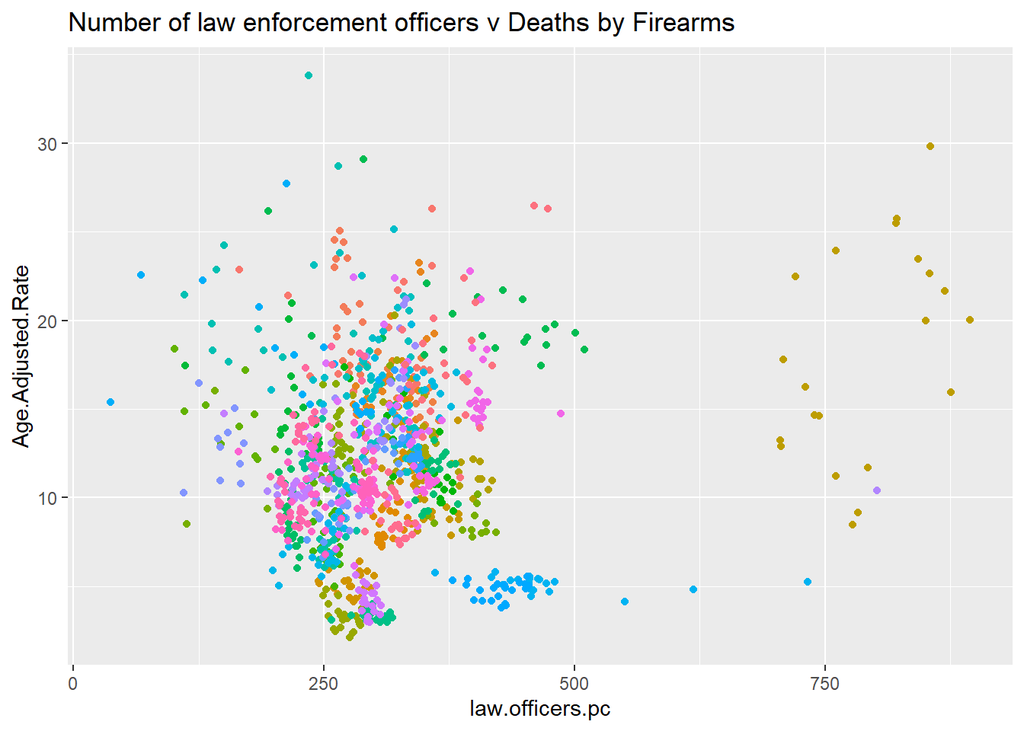

```r
ggplot(data2,aes(law.officers.pc,Age.Adjusted.Rate, color = State)) +
  geom_point() +
  guides(color = "none") + # removes the legend
  ggtitle("Number of law enforcement officers v Deaths by Firearms")
```

What you can see from here is that observations for the same state cluster together and that different states seem to differ significantly between each other. This variation is not reflected in the above estimation. In next week’s computer lab you will see how this issue can be tackled.

# Summary

In today’s computer lab you achieved a lot. You produced various plots and started to explore the amazing power of the ggplot package. You merged data, performed hypothesis tests and learned how to run and display multiple regressions.

TAKE A BREAK!